# Customer Service Requests Analysis

# 2. Data Wrangling and cleaning

```python
# Converting the zip code in to categorical variable from float
#try:
#    df_Customer_service_req["Incident Zip"] = df_Customer_service_req["Incident Zip"].astype(int).astype(str)
#except ValueError:
#    pass
```

```python
# Function to converter the date into correct format, I choose to leave the null as null as it cannot be dropped or been replaced with values that make sense to the data
#def date_formating(date):
#    if date==np.nan:
#        return np.nan
#    else:
#        try:
#            format_date=dateutil.parser.parse(date)
#            return format_date
#        except TypeError:
#            return np.nan
```

```python
# Converting the date column in to correct format
#df_Customer_service_req['Created Date']=df_Customer_service_req['Created Date'].apply(date_formating)
#df_Customer_service_req['Closed Date']=df_Customer_service_req['Closed Date'].apply(date_formating)
#df_Customer_service_req['Resolution Action Updated Date']=df_Customer_service_req['Resolution Action Updated Date'].apply(date_formating)"""
```

```python
# Converting the date column in to correct format
df_Customer_service_req['Created Date']=pd.to_datetime(df_Customer_service_req['Created Date'])
df_Customer_service_req['Closed Date']=pd.to_datetime(df_Customer_service_req['Closed Date'])
df_Customer_service_req['Resolution Action Updated Date']=pd.to_datetime(df_Customer_service_req['Resolution Action Updated Date'])
```

```python
# Creates new column "Request_Closing_time" which is elapsed time between request creation and closure
df_Customer_service_req['Request_Closing_time']=df_Customer_service_req['Closed Date']-df_Customer_service_req['Created Date']
```

```python
#List of clumns that has null values
null_columns = ["Descriptor","Location Type","Incident Zip","City"]
#List of cloumns that has null and needs to be replaced with numeric value
null_columns_num=["X Coordinate (State Plane)","Y Coordinate (State Plane)"
                         ,"Latitude","Longitude","Location"]
```

```python
df_Customer_service_req.isnull().sum()
```

```
Unique Key                             0
Created Date                           0
Closed Date                         2164
Agency                                 0
Agency Name                            0
Complaint Type                         0
Descriptor                          5914
Location Type                        131
Incident Zip                        2615
Incident Address                   44410
Street Name                        44410
Cross Street 1                     49279
Cross Street 2                     49779
Intersection Street 1             256840
Intersection Street 2             257336
Address Type                        2815
City                                2614
Landmark                          300349
Facility Type                       2171
Status                                 0
Due Date                               3
Resolution Description                 0
Resolution Action Updated Date      2187
Community Board                        0
Borough                                0
X Coordinate (State Plane)          3540
Y Coordinate (State Plane)          3540
Park Facility Name                     0
Park Borough                           0
School Name                            0
School Number                          0
School Region                          1
School Code                            1
School Phone Number                    0
School Address                         0
School City                            0
School State                           0
School Zip                             1
School Not Found                       0
School or Citywide Complaint      300698
Vehicle Type                      300698
Taxi Company Borough              300698
Taxi Pick Up Location             300698
Bridge Highway Name               300455
Bridge Highway Direction          300455
Road Ramp                         300485
Bridge Highway Segment            300485
Garage Lot Name                   300698
Ferry Direction                   300697
Ferry Terminal Name               300696
Latitude                            3540
Longitude                           3540
Location                            3540
Request_Closing_time                2164
dtype: int64
```

```python
# Handling null values
for col in null_columns:
    df_Customer_service_req[col].fillna((df_Customer_service_req[col].mode()[0]),inplace=True)
for col in null_columns_num:
    df_Customer_service_req[col].fillna(0,inplace=True)
```

```python
#List of columns that are either empty are not having sufficient data and can be dropped
#List of columns that may not be used or not needed will also be dropped
del_columns=['School Name','Incident Address','Street Name','Cross Street 1','Cross Street 2','Intersection Street 1'
             ,'Intersection Street 2',"Address Type",'School Number', 'School Region', 'School Code','Facility Type'
             ,'Park Borough','School Phone Number', 'School Address', 'School City', 'School State'
             ,'School Zip', 'School Not Found', 'School or Citywide Complaint','Vehicle Type'
             , 'Taxi Company Borough', 'Taxi Pick Up Location','Garage Lot Name','Community Board'
             ,'Ferry Direction','Ferry Terminal Name','Park Facility Name','Bridge Highway Direction'
             ,'Bridge Highway Segment','Road Ramp','Bridge Highway Name','Agency','Landmark','Unique Key']
```

```python
#Dropping the column that has no data
df_Customer_service_req.drop(del_columns,axis=1,inplace=True)
```

```python
# City names seems to have upper case and lower case and hence we need to convert all into upper case for proper grouping
df_Customer_service_req['City']=df_Customer_service_req['City'].apply(lambda x: x.upper())
```

```python
df_Customer_service_req.shape
```

```
(300698, 19)
```

```python
df_Customer_service_req.info()
```

```
<class 'pandas.core.frame.DataFrame'>
RangeIndex: 300698 entries, 0 to 300697
Data columns (total 19 columns):
 #   Column                          Non-Null Count   Dtype
---  ------                          --------------   -----
 0   Created Date                    300698 non-null  datetime64[ns]
 1   Closed Date                     298534 non-null  datetime64[ns]
 2   Agency Name                     300698 non-null  object
 3   Complaint Type                  300698 non-null  object
 4   Descriptor                      300698 non-null  object
 5   Location Type                   300698 non-null  object
 6   Incident Zip                    300698 non-null  float64
 7   City                            300698 non-null  object
 8   Status                          300698 non-null  object
 9   Due Date                        300695 non-null  object
 10  Resolution Description          300698 non-null  object
 11  Resolution Action Updated Date  298511 non-null  datetime64[ns]
 12  Borough                         300698 non-null  object
 13  X Coordinate (State Plane)      300698 non-null  float64
 14  Y Coordinate (State Plane)      300698 non-null  float64
 15  Latitude                        300698 non-null  float64
 16  Longitude                       300698 non-null  float64
 17  Location                        300698 non-null  object
 18  Request_Closing_time            298534 non-null  timedelta64[ns]
dtypes: datetime64[ns](3), float64(5), object(10), timedelta64[ns](1)
memory usage: 43.6+ MB
```

```python
df_Customer_service_req.isnull().sum()
```

```
Created Date                         0
Closed Date                       2164
Agency Name                          0
Complaint Type                       0
Descriptor                           0
Location Type                        0
Incident Zip                         0
City                                 0
Status                               0
Due Date                             3
Resolution Description               0
Resolution Action Updated Date    2187
Borough                              0
X Coordinate (State Plane)           0
Y Coordinate (State Plane)           0
Latitude                             0
Longitude                            0
Location                             0
Request_Closing_time              2164
dtype: int64
```

```python
df_Customer_service_req.tail()
```

|  | Created Date | Closed Date | Agency Name | Complaint Type | Descriptor | Location Type | Incident Zip | City | Status | Due Date | Resolution Description | Resolution Action Updated Date | Borough | X Coordinate (State Plane) | Y Coordinate (State Plane) | Latitude | Longitude | Location | Request_Closing_time |
| --- | --- | --- | --- | --- | --- | --- | --- | --- | --- | --- | --- | --- | --- | --- | --- | --- | --- | --- | --- |
| 300693 | 2015-03-29 00:33:41 | NaT | New York City Police Department | Noise - Commercial | Loud Music/Party | Club/Bar/Restaurant | 11385.0 | BROOKLYN | Open | 03/29/2015 08:33:41 AM | Your complaint has been forwarded to the New Y... | NaT | Unspecified | 0.0 | 0.0 | 0.000000 | 0.000000 | 0 | NaT |
| 300694 | 2015-03-29 00:33:28 | 2015-03-29 02:33:59 | New York City Police Department | Blocked Driveway | Partial Access | Street/Sidewalk | 11418.0 | RICHMOND HILL | Closed | 03/29/2015 08:33:28 AM | The Police Department responded and upon arriv... | 2015-03-29 02:33:59 | QUEENS | 1026931.0 | 192185.0 | 40.694077 | -73.846087 | (40.69407728322387, -73.8460866160573) | 0 days 02:00:31 |
| 300695 | 2015-03-29 00:33:03 | 2015-03-29 03:40:20 | New York City Police Department | Noise - Commercial | Loud Music/Party | Club/Bar/Restaurant | 11206.0 | BROOKLYN | Closed | 03/29/2015 08:33:03 AM | The Police Department responded to the complai... | 2015-03-29 03:40:20 | BROOKLYN | 999713.0 | 194161.0 | 40.699590 | -73.944234 | (40.69959035300927, -73.94423377144169) | 0 days 03:07:17 |
| 300696 | 2015-03-29 00:33:02 | 2015-03-29 04:38:35 | New York City Police Department | Noise - Commercial | Loud Music/Party | Club/Bar/Restaurant | 10461.0 | BRONX | Closed | 03/29/2015 08:33:02 AM | The Police Department responded to the complai... | 2015-03-29 04:38:35 | BRONX | 1030021.0 | 244520.0 | 40.837708 | -73.834587 | (40.8377075854206, -73.83458731019586) | 0 days 04:05:33 |
| 300697 | 2015-03-29 00:33:01 | 2015-03-29 04:41:50 | New York City Police Department | Noise - Commercial | Loud Music/Party | Store/Commercial | 10036.0 | NEW YORK | Closed | 03/29/2015 08:33:01 AM | The Police Department responded to the complai... | 2015-03-29 04:41:50 | MANHATTAN | 988150.0 | 216378.0 | 40.760583 | -73.985922 | (40.76058322950115, -73.98592204392392) | 0 days 04:08:49 |

# 3. Visualisation the data and inferring

```python
### Lets check the statistic description and correlation
```

```python
##df_Customer_service_req.describe()
```

```python
#px.box(df_Customer_service_req["Request_Closing_time"])
```

```python
##df_Customer_service_req.corr()
```

## Service Request City Wise

```python
# Lets see how the complains has spread to city wise
#df_Customer_service_req['City'].value_counts().plot.pie(autopct='%1.1f%%')
# Piechart seems to be toomuch clumsy
# However, it is show that the max number of complaints from Brooklyn
```

```
(0.0, 111013.1)
```

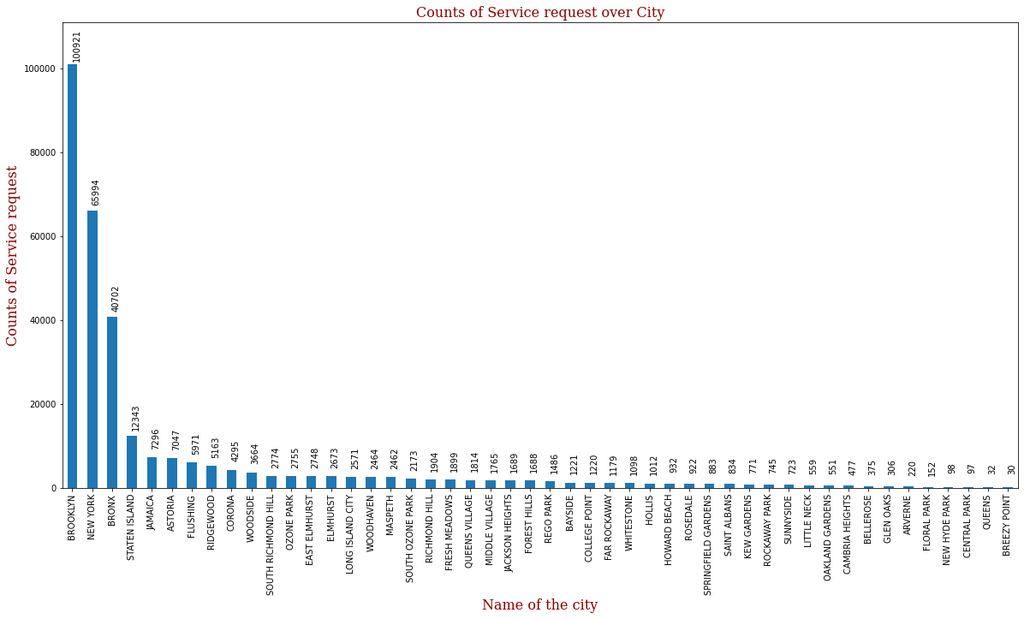

```python
# Let's visualise Counts of Service request over City in Bar plot
plt.figure(figsize=(20,10))
ys=df_Customer_service_req['City'].value_counts()
xs = np.arange(0,len(df_Customer_service_req['City'].unique()),1)
ys.plot.bar()
for x,y in zip(xs,ys.to_numpy()):
    label = y
    plt.annotate(label,(x,y+2500),rotation=90,textcoords="offset points",xytext=(0,10),verticalalignment='center')
plt.title("Counts of Service request over City",loc="center", fontdict= {'family': 'serif',
        'color':  'darkred',
        'weight': 'normal',
        'size': 16})
plt.xlabel("Name of the city",fontdict= {'family': 'serif',
        'color':  'darkred',
        'weight': 'normal',
        'size': 16})
plt.ylabel("Counts of Service request",fontdict= {'family': 'serif',
        'color':  'darkred',
        'weight': 'normal',
        'size': 16})
plt.ylim(0,(1.1*(max(ys))))
```

```python
df_Customer_service_req['Complaint Type'].value_counts()
```

```
Blocked Driveway             77044
Illegal Parking              75361
Noise - Street/Sidewalk      48612
Noise - Commercial           35577
Derelict Vehicle             17718
Noise - Vehicle              17083
Animal Abuse                  7778
Traffic                       4498
Homeless Encampment           4416
Noise - Park                  4042
Vending                       3802
Drinking                      1280
Noise - House of Worship       931
Posting Advertisement          650
Urinating in Public            592
Bike/Roller/Skate Chronic      427
Panhandling                    307
Disorderly Youth               286
Illegal Fireworks              168
Graffiti                       113
Agency Issues                    6
Squeegee                         4
Ferry Complaint                  2
Animal in a Park                 1
Name: Complaint Type, dtype: int64
```

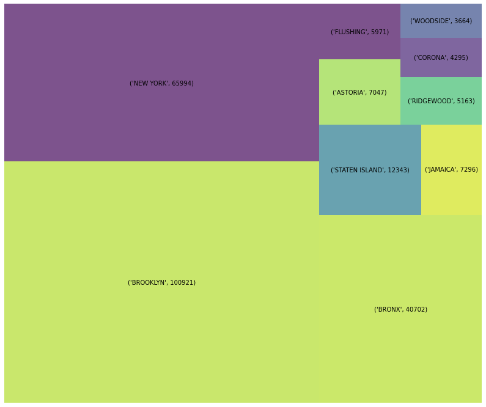

```python
# Vizualise the top 10 City with number of compliants in REctangular plot
citywise_complaints = pd.DataFrame(df_Customer_service_req['City'].value_counts()[:10])
fig = plt.gcf()
fig.set_size_inches(14, 12)
label=zip(list(citywise_complaints.index),citywise_complaints['City'])
squarify.plot(sizes=citywise_complaints['City'], label=label, alpha=0.7,)
plt.axis('off')
plt.show()
```

- Brooklyn has top most service request with 100921 instance (33%)
- New York has second most service request with 65994 instance (22%)

## Status of the Service Request

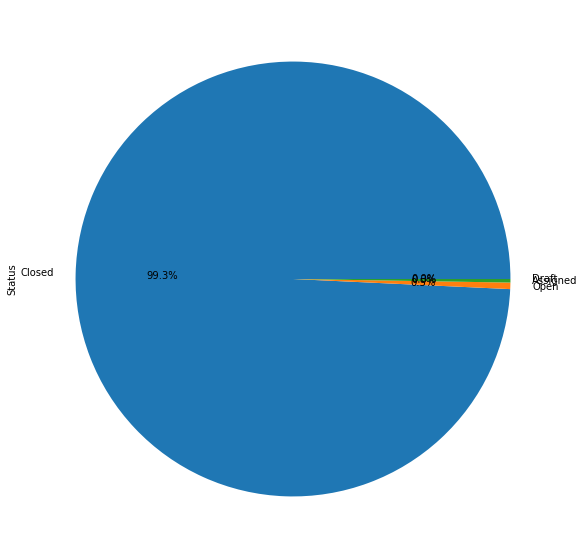

```python
# Let's visualise the compliant in pie chart
plt.figure(figsize=(20,10))
ys=df_Customer_service_req['Status'].value_counts()
ys.plot.pie(autopct='%1.1f%%')
```

#### Status of the Request

- 99.3% of the request is Closed

```python
df_Customer_service_req[['Status','Agency Name','City']].groupby(['Status','Agency Name'],as_index=False).agg('count').rename(columns={'City':'Count'})
```

|  | Status | Agency Name | Count |
| --- | --- | --- | --- |
| 0 | Assigned | NYPD | 1 |
| 1 | Assigned | New York City Police Department | 785 |
| 2 | Closed | Internal Affairs Bureau | 6 |
| 3 | Closed | New York City Police Department | 298465 |
| 4 | Draft | NYPD | 1 |
| 5 | Draft | New York City Police Department | 1 |
| 6 | Open | New York City Police Department | 1439 |

- Only "New York City Police Department" has request in Open status
- Out of all request only 6 request where raised to Internal Affairs Bureau

## Spread of Complaint Types

```python
#df_Customer_service_req["Complaint Type"].value_counts().plot.pie(autopct='%1.1f%%')
# Piechart seems to be toomuch clumsy
```

```
(0.0, 84748.40000000001)
```

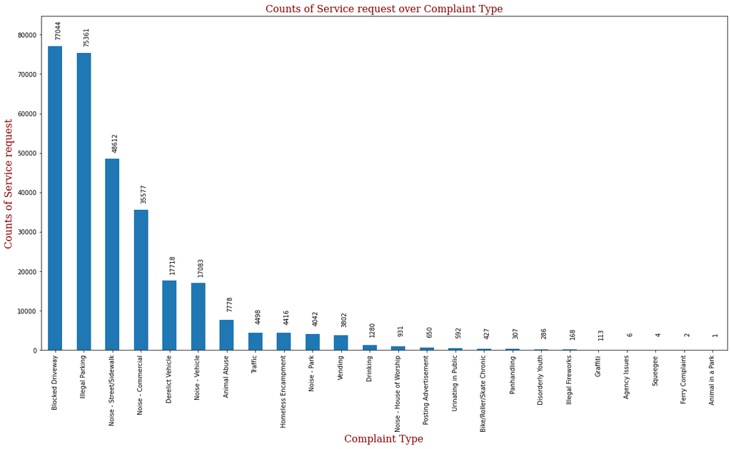

```python
plt.figure(figsize=(20,10))
ys=df_Customer_service_req['Complaint Type'].value_counts()
xs = np.arange(0,len(df_Customer_service_req['Complaint Type'].unique()),1)
ys.plot.bar()
for x,y in zip(xs,ys.to_numpy()):
    label = y
    plt.annotate(label,(x,y+2500),rotation=90,textcoords="offset points",xytext=(0,10),verticalalignment='center')
plt.title("Counts of Service request over Complaint Type",loc="center", fontdict= {'family': 'serif',
        'color':  'darkred',
        'weight': 'normal',
        'size': 16})
plt.xlabel("Complaint Type",fontdict= {'family': 'serif',
        'color':  'darkred',
        'weight': 'normal',
        'size': 16})
plt.ylabel("Counts of Service request",fontdict= {'family': 'serif',
        'color':  'darkred',
        'weight': 'normal',
        'size': 16})
plt.ylim(0,(1.1*(max(ys))))
```

- Complaint "Blocked Driveway" is the most registered complaint with 25.6%
- Complaint "Illegal parking" is the second most registered complaint with 25.1%
- Above two type of complaint are relatively major compared to others with total of ~50% of complaint

```python
list(df_Customer_service_req['Complaint Type'].value_counts().index)[0:5]
```

```
['Blocked Driveway',
 'Illegal Parking',
 'Noise - Street/Sidewalk',
 'Noise - Commercial',
 'Derelict Vehicle']
```

```python
# Lets see top 6 Compliants
top6_complaints = list(df_Customer_service_req['Complaint Type'].value_counts().index)[0:6]
complinats_borough = df_Customer_service_req.groupby(['Borough','Complaint Type']).size().unstack()
complinats_borough = complinats_borough[top6_complaints]
complinats_borough
```

| Complaint Type Borough | Blocked Driveway | Illegal Parking | Noise - Street/Sidewalk | Noise - Commercial | Derelict Vehicle | Noise - Vehicle |
| --- | --- | --- | --- | --- | --- | --- |
| BRONX | 12755.0 | 7859.0 | 8891.0 | 2434.0 | 1953.0 | 3396.0 |
| BROOKLYN | 28148.0 | 27462.0 | 13355.0 | 11463.0 | 5181.0 | 5177.0 |
| MANHATTAN | 2073.0 | 12132.0 | 20550.0 | 14560.0 | 537.0 | 5485.0 |
| QUEENS | 31644.0 | 21982.0 | 4407.0 | 6075.0 | 8110.0 | 2615.0 |
| STATEN ISLAND | 2142.0 | 4886.0 | 820.0 | 679.0 | 1766.0 | 356.0 |
| Unspecified | 282.0 | 1040.0 | 589.0 | 366.0 | 171.0 | 54.0 |

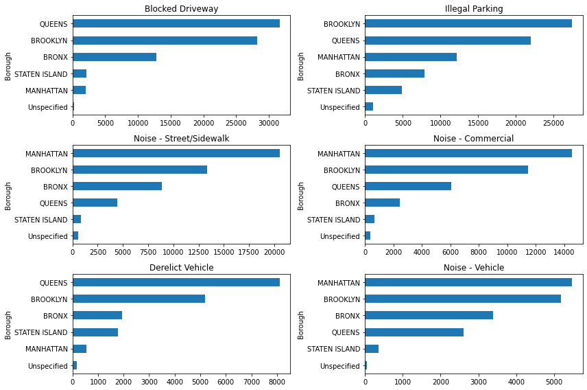

```python
col_number = 2
row_number = 3
fig, axes = plt.subplots(row_number,col_number, figsize=(12,8))

for i, (label,col) in enumerate(complinats_borough.iteritems()):
    ax = axes[int(i/col_number), i%col_number]
    col = col.sort_values(ascending=True)[:15]
    col.plot(kind='barh', ax=ax)
    ax.set_title(label)

plt.tight_layout()
```

- When it comes to Noise related complaint Manhattan stays on top
- When it comes to Derelict Vehicle/Blocked Blocked Driveway/Illegal Parking Queens and Brooklyn stays on top

# Descriptor

```
(0.0, 74078.40000000001)
```

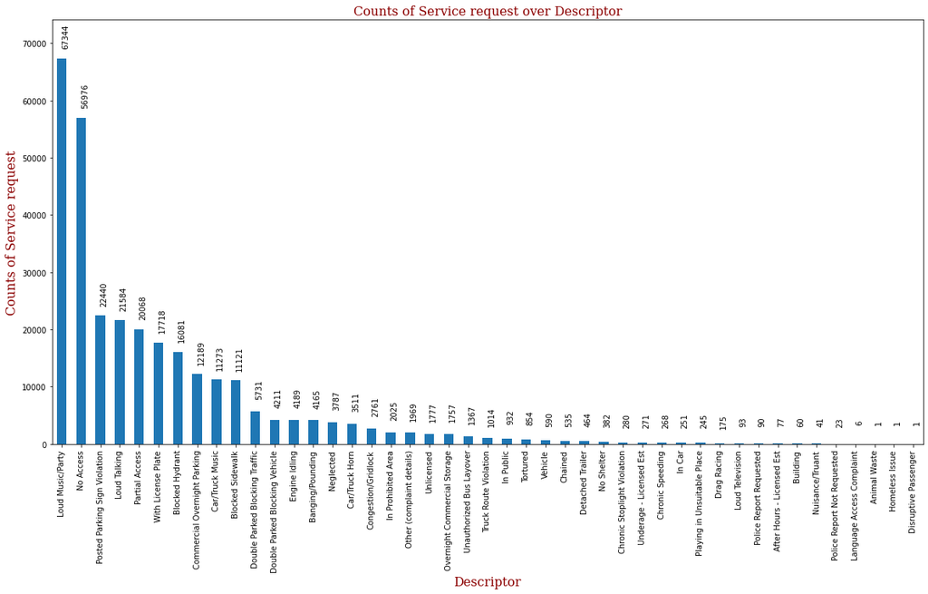

```python
plt.figure(figsize=(20,10))
ys=df_Customer_service_req['Descriptor'].value_counts()
xs = np.arange(0,len(df_Customer_service_req['Descriptor'].unique()),1)
ys.plot.bar()
for x,y in zip(xs,ys.to_numpy()):
    label = y
    plt.annotate(label,(x,y+2500),rotation=90,textcoords="offset points",xytext=(0,10),verticalalignment='center')
plt.title("Counts of Service request over Descriptor",loc="center", fontdict= {'family': 'serif',
        'color':  'darkred',
        'weight': 'normal',
        'size': 16})
plt.xlabel("Descriptor",fontdict= {'family': 'serif',
        'color':  'darkred',
        'weight': 'normal',
        'size': 16})
plt.ylabel("Counts of Service request",fontdict= {'family': 'serif',
        'color':  'darkred',
        'weight': 'normal',
        'size': 16})
plt.ylim(0,(1.1*(max(ys))))
```

- Loud Music/Party are the most described compliant

```python
#df_Customer_service_req["Complaint Type"].value_counts().sort_values(ascending=False).index[0:5]
```

```python
df_Customer_service_req.groupby(["Borough","Complaint Type"]).size().unstack()[df_Customer_service_req["Complaint Type"].value_counts().sort_values(ascending=False).index[0:5]]
```

| Complaint Type Borough | Blocked Driveway | Illegal Parking | Noise - Street/Sidewalk | Noise - Commercial | Derelict Vehicle |
| --- | --- | --- | --- | --- | --- |
| BRONX | 12755.0 | 7859.0 | 8891.0 | 2434.0 | 1953.0 |
| BROOKLYN | 28148.0 | 27462.0 | 13355.0 | 11463.0 | 5181.0 |
| MANHATTAN | 2073.0 | 12132.0 | 20550.0 | 14560.0 | 537.0 |
| QUEENS | 31644.0 | 21982.0 | 4407.0 | 6075.0 | 8110.0 |
| STATEN ISLAND | 2142.0 | 4886.0 | 820.0 | 679.0 | 1766.0 |
| Unspecified | 282.0 | 1040.0 | 589.0 | 366.0 | 171.0 |

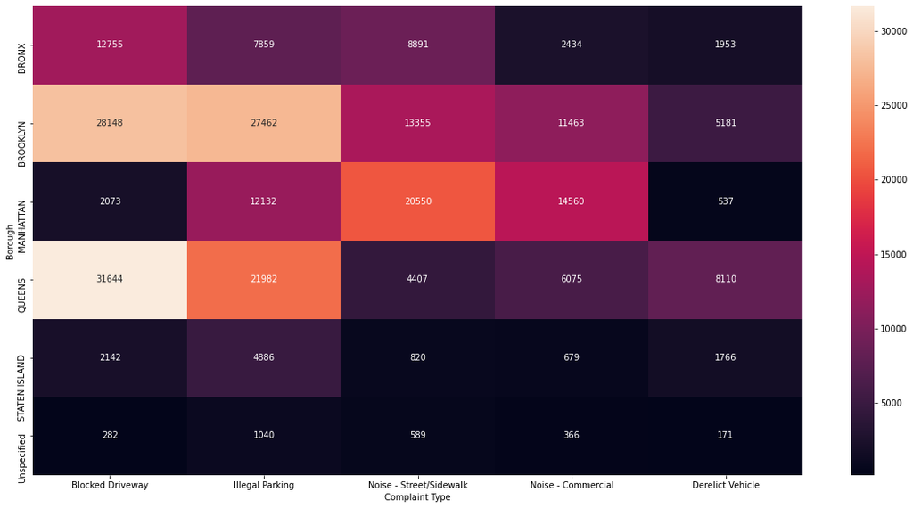

```python
plt.figure(figsize=(20,10))
sns.heatmap(df_Customer_service_req.groupby(["Borough","Complaint Type"]).size().unstack()[df_Customer_service_req["Complaint Type"].value_counts().sort_values(ascending=False).index[0:5]],annot=True,fmt='g')
```

- The above heat map shows that the compliant type across the city wise
- The city Queens and compliant type Blocked driveway are of maximum compared to other city and compliant type combination
- The city Brooklyn and compliant type Blocked driveway/Illegal parking are also high compared to other city and compliant type combination
- This implies that the Queens and Brooklyn most likely have the compliant type Blocked driveway or Illegal parking mostly
- This very much matched with the previous inference on Compliant type where Blocked driveway/Illegal parking contributes to 50% of the total compliant

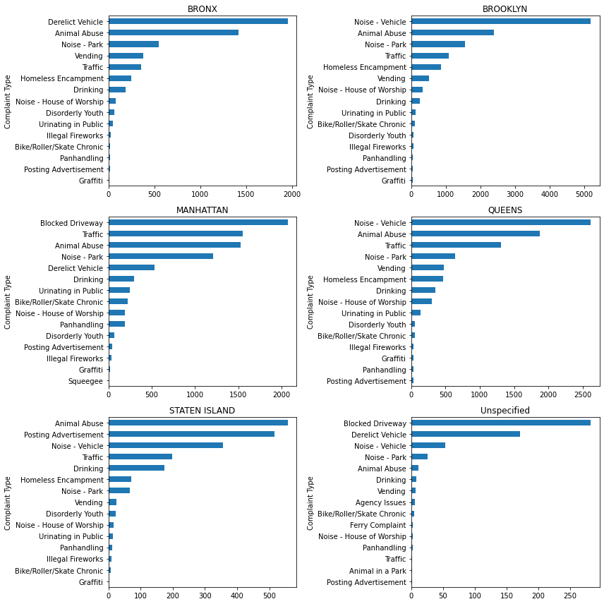

```python
# Visualization of most Complaints per Borough
borough_comp = df_Customer_service_req.groupby(['Complaint Type','Borough']).size().unstack()

col_number = 2
row_number = 3
fig, axes = plt.subplots(row_number,col_number, figsize=(12,12))

for i, (label,col) in enumerate(borough_comp.iteritems()):
    ax = axes[int(i/col_number), i%col_number]
    col = col.sort_values(ascending=True)[:15]
    col.plot(kind='barh', ax=ax)
    ax.set_title(label)

plt.tight_layout()
```

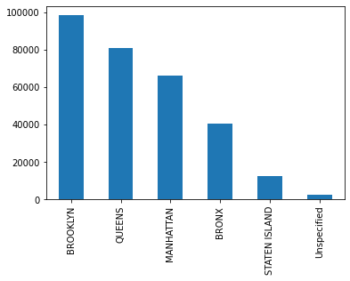

```python
df_Customer_service_req['Borough'].value_counts().plot(kind='bar')
```

- Borough wise, Brooklyn has the most number of Complaints followed by Queens and Manhattan.